# Lab 3

## Univariate Linear Regression on the California Housing Prices Dataset

The following task is on the training of a machine learning model based on a univariate linear regression. The data source is from california housing pricess dataset(link to data) [link to data](https://www.kaggle.com/datasets/camnugent/california-housing-prices/download?datasetVersionNumber=1) , having the following features.

Data Features:

longitude latitude  
housing_median_age  
total_rooms total_bedrooms  
population  
households  
median_income median_house_value

1. Median house values vs Median Income values
2. Median house value vs Population values
3. Median house value vs Household values

```python
import pandas as pd
import plotly.express as px

import seaborn as sns
from sklearn.metrics import mean_absolute_error, mean_squared_error
import matplotlib.pyplot as plt

from sklearn import linear_model

model = linear_model.LinearRegression()


df = pd.read_csv("data/housing.csv")
```

## Data-set description

```python
print(df.describe())

print(df['median_house_value'].describe())

print(df['median_income'].describe())

print(df['population'].describe())

print(df['households'].describe())

df.head()
```

```
          longitude      latitude  housing_median_age   total_rooms
count  20640.000000  20640.000000        20640.000000  20640.000000  \
mean    -119.569704     35.631861           28.639486   2635.763081
std        2.003532      2.135952           12.585558   2181.615252
min     -124.350000     32.540000            1.000000      2.000000
25%     -121.800000     33.930000           18.000000   1447.750000
50%     -118.490000     34.260000           29.000000   2127.000000
75%     -118.010000     37.710000           37.000000   3148.000000
max     -114.310000     41.950000           52.000000  39320.000000

       total_bedrooms    population    households  median_income
count    20433.000000  20640.000000  20640.000000   20640.000000  \
mean       537.870553   1425.476744    499.539680       3.870671
std        421.385070   1132.462122    382.329753       1.899822
min          1.000000      3.000000      1.000000       0.499900
25%        296.000000    787.000000    280.000000       2.563400
50%        435.000000   1166.000000    409.000000       3.534800
75%        647.000000   1725.000000    605.000000       4.743250
max       6445.000000  35682.000000   6082.000000      15.000100

       median_house_value
count        20640.000000
mean        206855.816909
std         115395.615874
min          14999.000000
25%         119600.000000
50%         179700.000000
75%         264725.000000
max         500001.000000
count     20640.000000
mean     206855.816909
std      115395.615874
min       14999.000000
25%      119600.000000
50%      179700.000000
75%      264725.000000
max      500001.000000
Name: median_house_value, dtype: float64
count    20640.000000
mean         3.870671
```

[output cut: 10 more lines]

```
min          3.000000
25%        787.000000
50%       1166.000000
75%       1725.000000
max      35682.000000
Name: population, dtype: float64
count    20640.000000
mean       499.539680
std        382.329753
min          1.000000
25%        280.000000
50%        409.000000
75%        605.000000
max       6082.000000
Name: households, dtype: float64
```

|  | longitude | latitude | housing_median_age | total_rooms | total_bedrooms | population | households | median_income | median_house_value | ocean_proximity |
| --- | --- | --- | --- | --- | --- | --- | --- | --- | --- | --- |
| 0 | -122.23 | 37.88 | 41.0 | 880.0 | 129.0 | 322.0 | 126.0 | 8.3252 | 452600.0 | NEAR BAY |
| 1 | -122.22 | 37.86 | 21.0 | 7099.0 | 1106.0 | 2401.0 | 1138.0 | 8.3014 | 358500.0 | NEAR BAY |
| 2 | -122.24 | 37.85 | 52.0 | 1467.0 | 190.0 | 496.0 | 177.0 | 7.2574 | 352100.0 | NEAR BAY |
| 3 | -122.25 | 37.85 | 52.0 | 1274.0 | 235.0 | 558.0 | 219.0 | 5.6431 | 341300.0 | NEAR BAY |
| 4 | -122.25 | 37.85 | 52.0 | 1627.0 | 280.0 | 565.0 | 259.0 | 3.8462 | 342200.0 | NEAR BAY |

## Seaborn Scatter Plot for Media House values vs Median Income values

[figure not shown]

```python
sns.scatterplot(x="median_income", y="median_house_value", data=df, color="blue").set_title('Median House value vs. Median Income')
```

## Seaborn Scatter Plot for Media House values vs Population

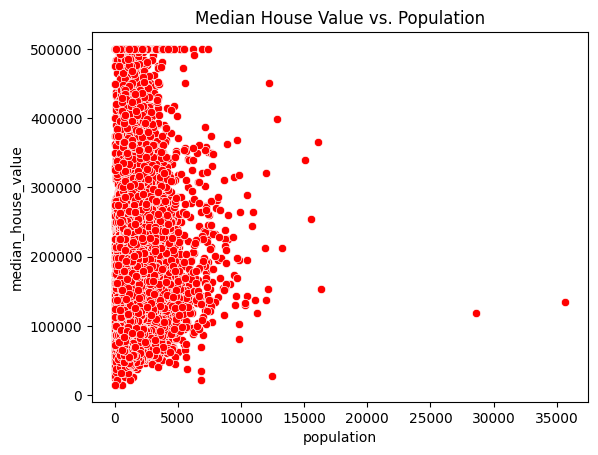

```python
sns.scatterplot(x="population", y="median_house_value", data=df, color="red").set_title('Median House Value vs. Population')
```

## Seaborn Scatter Plot for Media House values vs Number Of Households

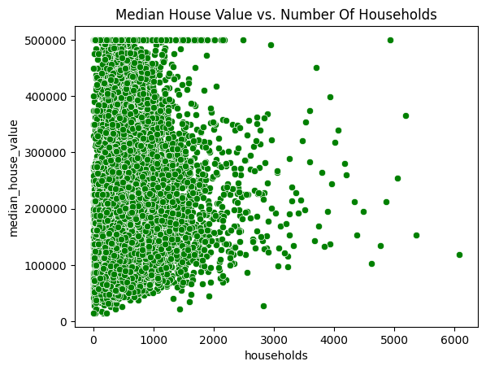

```python
sns.scatterplot(x="households", y="median_house_value", data=df, color="green").set_title('Median House Value vs. Number Of Households')
```

## Plot for the median income against the media house value showing the resulting line from the predictions of the media income values

```
Intercept: [45085.57670327]
mean_absolute_error: 62625.9337911434
mean_square_error: 7011311502.929527
```

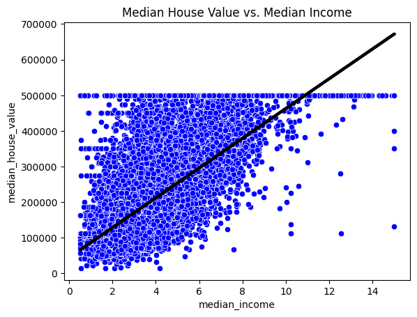

```python
model.fit(X=df[["median_income"]], y=df[["median_house_value"]])

print(f"Intercept: {model.intercept_}")

vm = model.predict(X=df[["median_income"]])

print(f"mean_absolute_error: {mean_absolute_error(df[['median_house_value']], vm)}")

print(f"mean_square_error: {mean_squared_error(df[['median_house_value']], vm)}")


sns.scatterplot(x="median_income", y="median_house_value", data=df, color="blue").set_title('Median House Value vs. Median Income')

plt.plot(df[["median_income"]], model.predict(df[["median_income"]]), color="black", linewidth=3)

plt.show()
```

## Plot for the population against the media house value showing the resulting line from the predictions of the population values

```
Intercept: [210436.26207627]
mean_absolute_error: 91153.8200947318
mean_square_error: 13307412412.389355
```

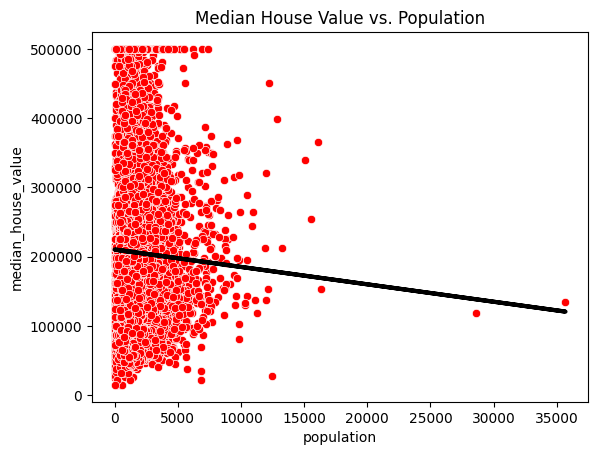

```python
model.fit(X=df[["population"]], y=df[["median_house_value"]])

print(f"Intercept: {model.intercept_}")

vp = model.predict(X=df[["population"]])

print(f"mean_absolute_error: {mean_absolute_error(df[['median_house_value']], vp)}")

print(f"mean_square_error: {mean_squared_error(df[['median_house_value']], vp)}")


sns.scatterplot(x="population", y="median_house_value", data=df, color="red").set_title('Median House Value vs. Population')

plt.plot(df[["population"]], model.predict(df[["population"]]), color="black", linewidth=3)

plt.show()
```

## Plot for the number of households against the media house value showing the resulting line from the predictions of the households values

```
Intercept: [196928.57716233]
mean_absolute_error: 90802.74324318446
mean_square_error: 13257776904.728533
```

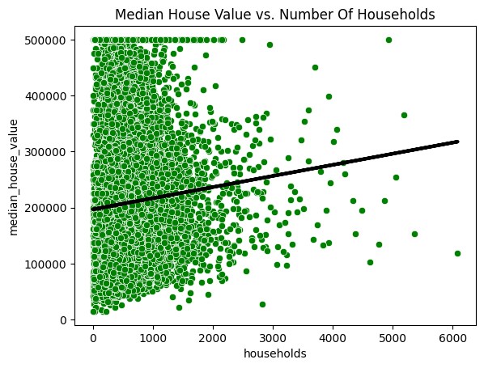

```python
model.fit(X=df[["households"]], y=df[["median_house_value"]])

sns.scatterplot(x="households", y="median_house_value", data=df, color="green").set_title('Median House Value vs. Number Of Households')

plt.plot(df[["households"]], model.predict(df[["households"]]), color="black", linewidth=3)

print(f"Intercept: {model.intercept_}")

vd = model.predict(X=df[["households"]])

print(f"mean_absolute_error: {mean_absolute_error(df[['median_house_value']], vd)}")

print(f"mean_square_error: {mean_squared_error(df[['median_house_value']], vd)}")


plt.show()
```

The follow table describes the interceps, Mean Square Error, Mean Absolute Error

| Plot | Intercept | Mean Square Error | Mean Absolute Error |
| --- | --- | --- | --- |
| Median House Value Vs. Median Income | 45085.57670327 | 7011311502.929527 | 62625.9337911434 |
| Median House Value Vs. Population | 210436.26207627 | 13307412412.389355 | 91153.8200947318 |
| Median House Value Vs. Households | 196928.57716233 | 13257776904.728533 | 90802.74324318446 |

# Conclusion

From the above Plots, one of the goodness of fit, is that it tells you direction of the the independent variables, for example, the resulting line from the

Median House Value vs Median Income shows that the median income increases as the median house value increases, whereas population value reduces as the median house value increases. This insight was seen at first glance using the line derived from the predicted values as a result of the model fit.